# HW6

11

October 18, 2016

We will use the bootstrap technique to generate confidence intervals

1. Suppose we have a sample of data from an exponential distribution with parameter lambda. In this case use lambda.hat = 1/mean(X).

As the number of observations increases, does the estimate for lambda become roughly normally distributed? We will answer this question in the following parts.

1a. (1) Generate 100 observations of test data, with lambda=3. Remember to set your seed before carrying out any computations.

```r
set.seed(0)
lambda = 3

expon_sample = rexp(100, lambda)
```

1b. (1) What is the mean of your test data? (give the code and the value)

```r
mean(expon_sample)
```

```
## [1] 0.344049
```

1c. (1) What is your estimate lambda.hat? (give the code and the value)

```r
lambda.hat = 1/mean(expon_sample)
lambda.hat
```

```
## [1] 2.906563
```

2. Now use the bootstrap to estimate the distribution of lambda.hat and create bootstrap confidence intervals for lambda, rather than the approach in 1).

2a. (1) Form a set of bootstrap estimates of our parameter by generating B random samples as you did once in 1a but use lambda.hat since we do not know the true lambda in this case (keep n=100). Set B=1000, and again set your seed.

```r
B=1000
set.seed(0)
bootstrap.lambda.hats = replicate(B,1/mean(rexp(100, lambda.hat)))
```

2b. (1) Get a new estimate for lambda.hat from each of the bootstrap samples in 2a. You’ll want to create a matrix to receive each value. You should have 1000 estimates for lambda.hat now.

```r
bootstrap.lambda.hats = matrix(bootstrap.lambda.hats, nrow=B)
```

2c. (2) Now look at the sampling distribution for lambda.hat, using the hist function. Remember the graphing techniques discussed in class and use them to make the plot look professional. Does the distribution look normal?

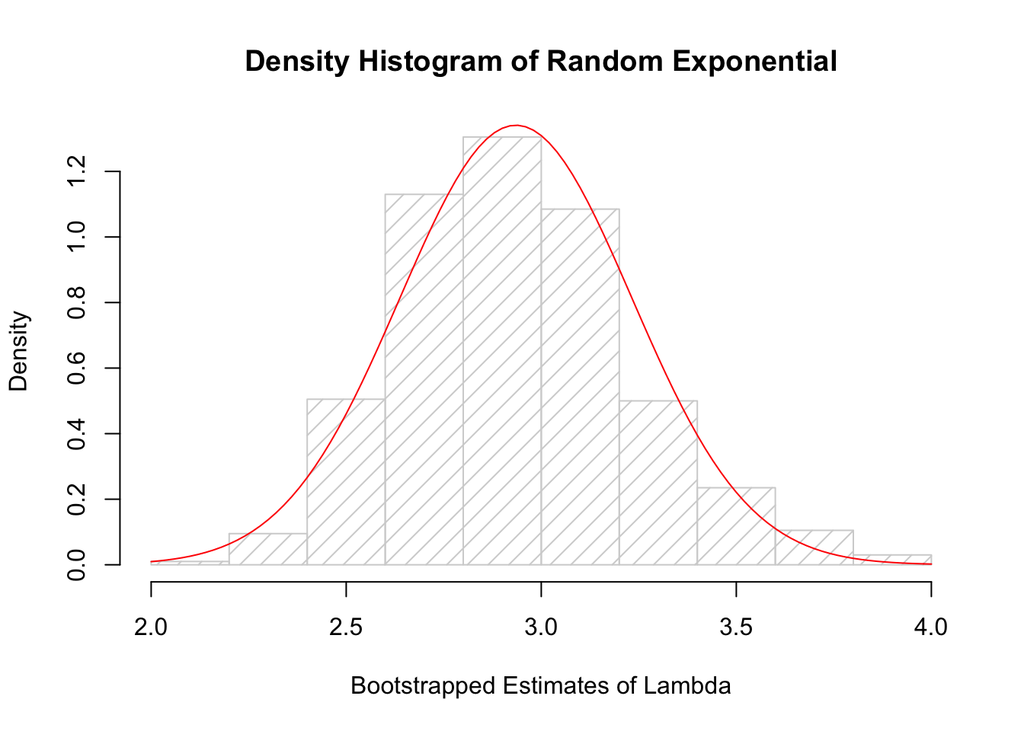

```r
hist(bootstrap.lambda.hats, freq=F, col="lightgray", density=10,main="Density Histogram of Random Exponential",xlab="Bootstrapped Estimates of Lambda")
curve(dnorm(x, mean(bootstrap.lambda.hats), sd(bootstrap.lambda.hats)), col="red", add=TRUE)
```

2d. (1) Calculate an estimate of the standard error of lambda.hat using your collection of bootstrap estimated parameters. What is your 95% confidence interval?

```r
stder = sd(bootstrap.lambda.hats)

lower = lambda.hat - qnorm(1-(0.05)/2) * stder
upper = lambda.hat + qnorm(1-(0.05)/2) * stder

print(paste0("Confidence Interval: [", lower, ", ", upper, "]"))
```

```
## [1] "Confidence Interval: [2.32344242400916, 3.48968309304033]"
```

3a. (5) We made some decisions when we used the bootstrap above that we can now question. Repeat the above creation of a confidence interval for a range of values of data (we had our sample size fixed at 100) and a range of bootstrap values (we had B fixed at 1000). Suppose the sample size varies (100, 200, 300, …. , 1000) and B varies (1000, 2000, … , 10000). You will likely find it useful to write functions to carry out these calculations. Your final output should be upper and lower pairs for the confidence intervals produced using the bootstrap method for each value of sample size and B. Generalize 2b into a function, and vary inputs of sample size and B as we did above.

```r
boot.sample = function(sample.size, B){
    set.seed(0)
    return(matrix(replicate(B,1/mean(rexp(sample.size, lambda.hat))), nrow=B))
}

sizes = seq(100, 1000, by=100)
Bs = seq(1000, 10000, by=1000)
lower = numeric()
upper = numeric()

for(i in 1:length(sizes)) {
    for(j in 1:length(Bs)){
        sampEr = sd(boot.sample(sizes[i], Bs[j]))
        lower = c(lower, lambda.hat - qnorm(1-(0.05)/2) * sampEr)
        upper = c(upper, lambda.hat + qnorm(1-(0.05)/2) * sampEr)
    }
}
```

3b. (2) Plot your CI limits to show the effect of changing the sample size and changing the number of bootstrap replications. What do you conclude?

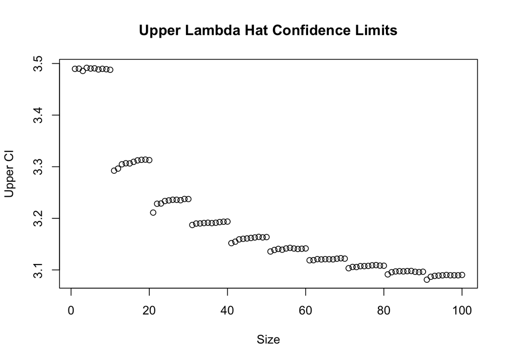

```r
plot(upper, main="Upper Lambda Hat Confidence Limits",xlab="Size", ylab="Upper CI")
```

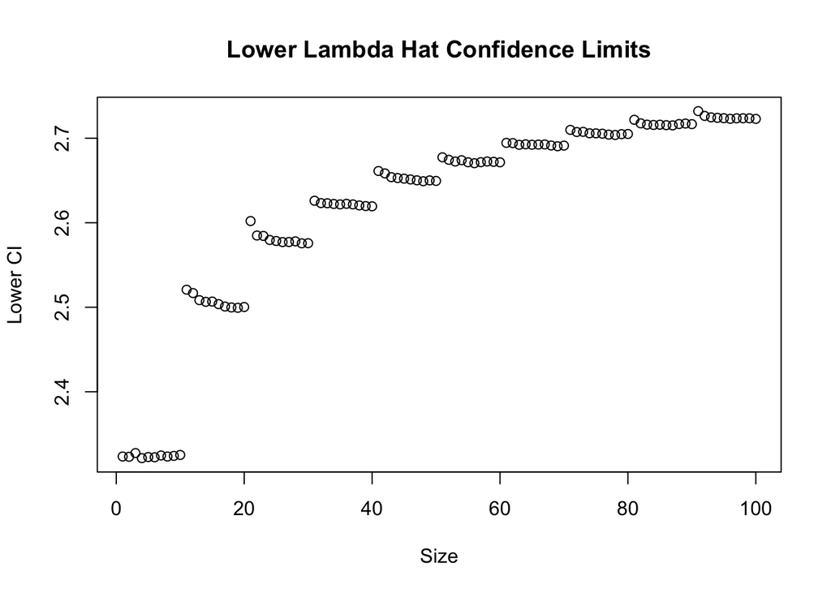

```r
plot(lower, main="Lower Lambda Hat Confidence Limits",xlab="Size", ylab="Lower CI")
```

As the sample size increases, both the low and high cofidence limits approach 3.

4a. (5) In 1961 John Tukey wrote an article called The Future of Data Analysis(it is uploaded in moodle). Some people say it is prophetic regarding the field of Data Science today. Do you agree or disagee? Why or why not? (Please keep your answer less than 500 words).

I agree that John Tukey’s article called “The Future of Data Analysis” could be regarded as prophetic with respect to the field of Data Science today. Tukey emphsizes increased reliance on computers for the purpose of data analysis. In particular, he says that “it is not sufficient to start with what is desired to estimate, and to study how well an estimator succeeds in doing this”. That is, rather than starting with an a-priori judgement about the data and seeing how well a modelfits the assumption; proper treatment of the data would require starting without a prior and extracting indicators during analysis. He continues by saying that graphical techniques offer great possibilities in this respect and so, graphs will be increasingly “drawn” by the computer without being touched by hands. This is certainly, appears to be the case today, especially with regard to large data sets. The complexities of working with Big Data, almost force modern data scientists to isolate new “signals” in their research rather than using the data to support a prior bias.

4b. (5) Relate the article to the Life Cycle of Data discussion from class. You may wish to choose an example or idea from the article and clearly explore how it relates to the Life Cycle of Data. (Please keep your answer less than 500 words).

In the section “What are the necessary attitudes?” Tukey said that, “We must expect to tackle more realistic problems than our teachers did, and expect our successors to tackle problems which are more realistic than those we ourselves dared to take on.” In other words, we should expect our analyses of data to be less abstract, have fewer assumptions, and generally be more realistic, as time progresses. This is precisely what the Life Cycle of Data attempts to capture. By properly documenting our data, and preserving it for future use, we are allowing “our successors” to use our data to tackle problems which are more realistic than the ones we studied.